# Estimating Joint Survival and Marker Models

## dummy slide

# Introduction

## Markers

## Example: One individual

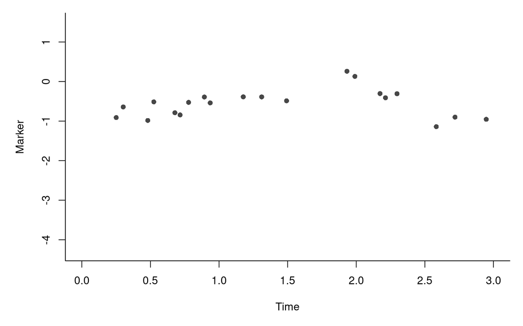

## Example: Two individuals

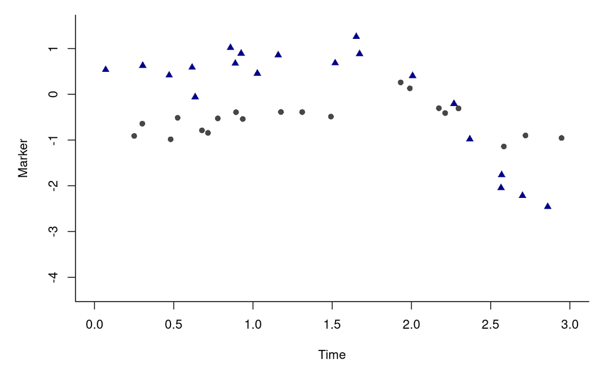

## Example: Two individuals

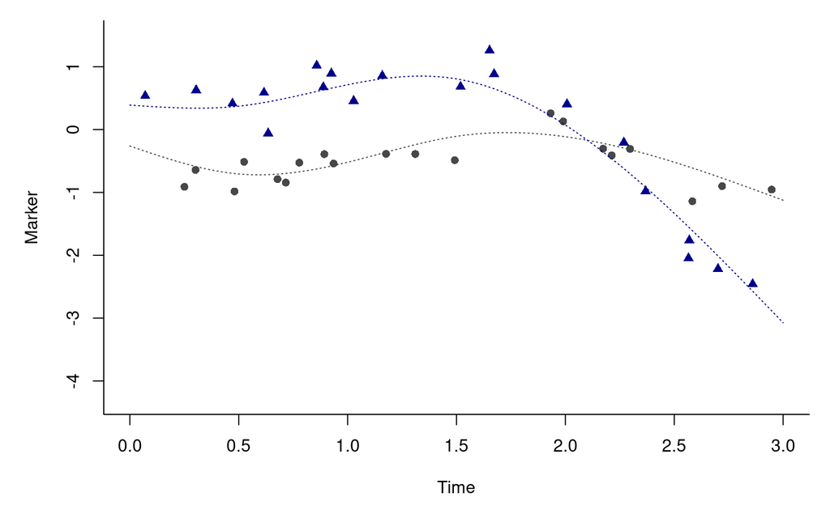

## Example: Population Curves

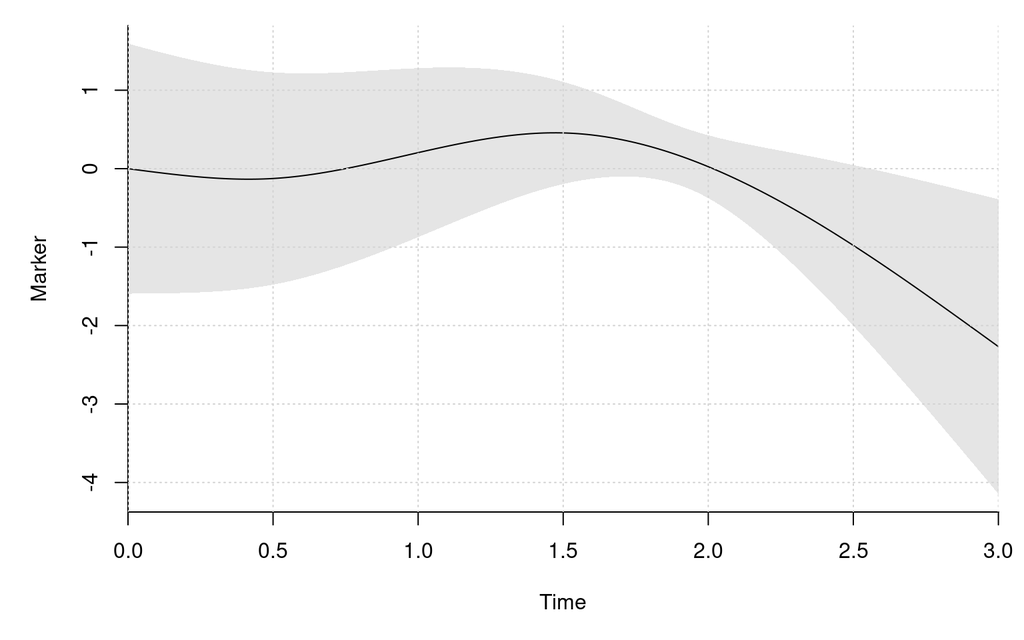

## Example: Population Curves

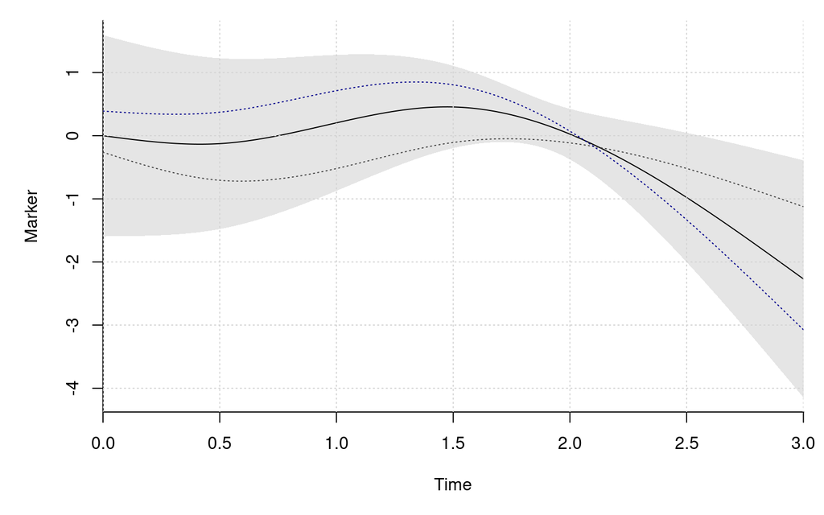

## Example: Population Curves

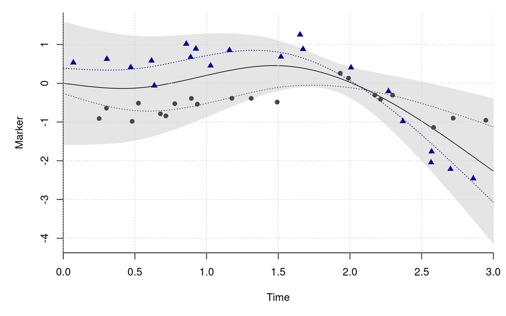

## Do not know

# Simulation Study

## Setup

## Mean Marker Curve

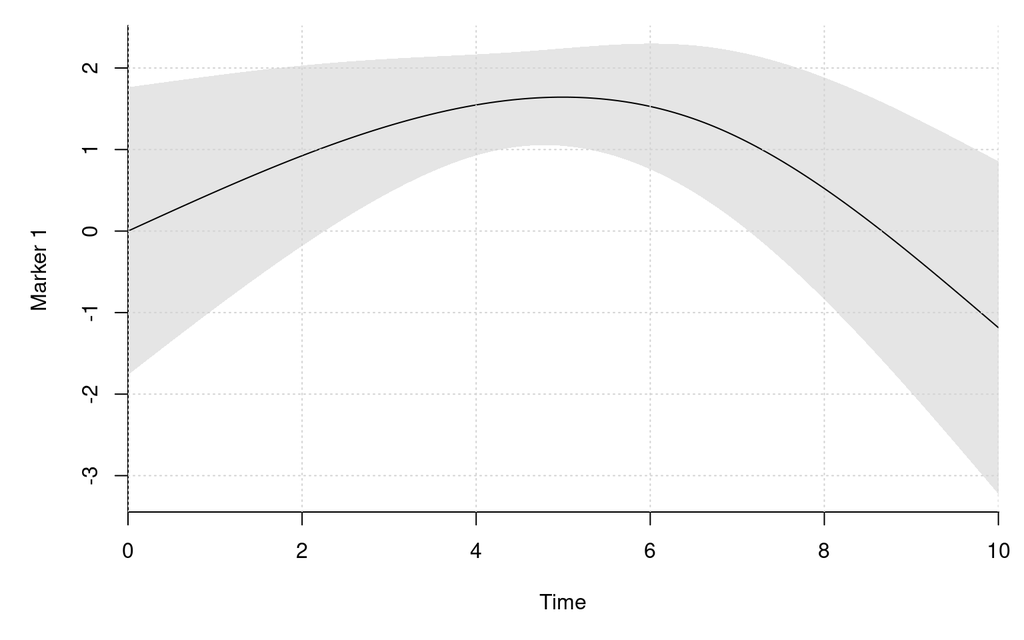

## Mean Marker Curve

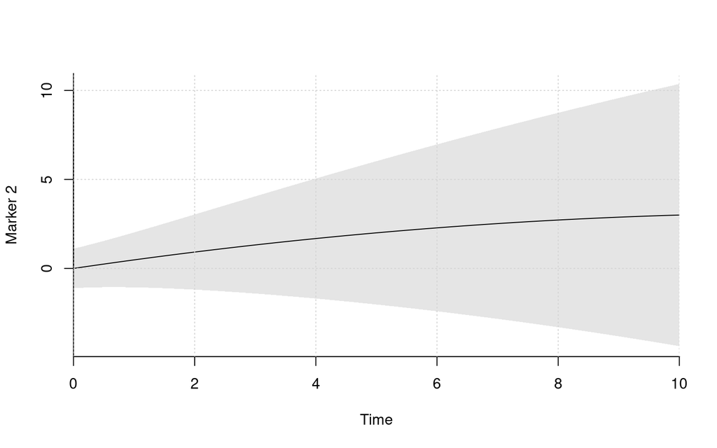

## Hazard Curves: Terminal

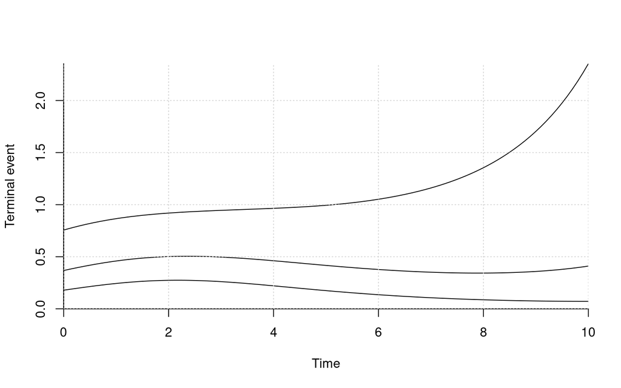

## Hazard Curves: Observation Process

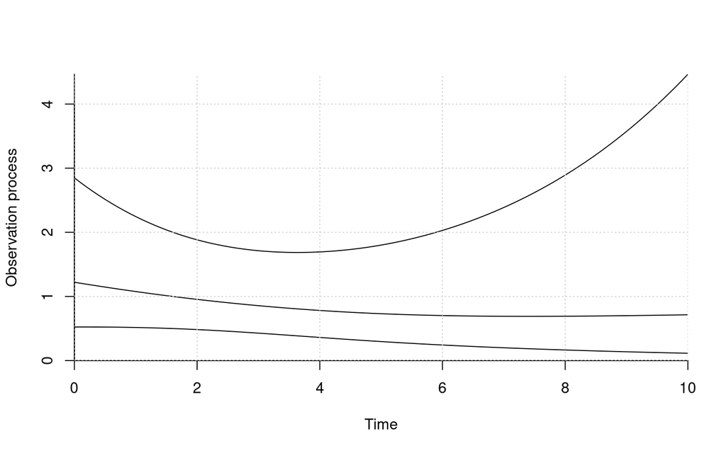

## Results

## Results

|  | Terminal |  | Observation |  |
| --- | --- | --- | --- | --- |
| Marker 1 | -0.133 | 0.684 | 0.243 | 0.345 |
| Marker 2 | 0.341 | 0.383 | -0.133 | 0.212 |

Average computation time $111.299 \pm 2.943$. Bias estimates for the association parameters, $\vec\alpha_1$ and $\vec\alpha_2$, are shown above multiplied by 100.

## Results

|  | Terminal |  | Observation |  |
| --- | --- | --- | --- | --- |
|  | -2.295 | 1.082 | 0.807 | 0.469 |
|  | 0.314 | 0.643 |  |  |

Bias estimates for the time-varying fixed effects of the survival outcomes, $\vec\delta_1$ and $\vec\delta_2$, are shown above multiplied by 100.

## Results

|  | Terminal |  | Observation |  |
| --- | --- | --- | --- | --- |
|  | 6.46 | 2.65 | -5.26 | 1.97 |
|  | -12.56 | 4.70 | -3.06 | 2.02 |
|  | 11.87 | 7.03 |  |  |
|  | -33.21 | 11.42 |  |  |

Bias estimates for the fixed effects of the survival outcomes, $\vec\omega_1$ and $\vec\omega_2$, are shown above multiplied by 100.

## Results

|  | Bias |  |  |  |  | SE |  |  |  |
| --- | --- | --- | --- | --- | --- | --- | --- | --- | --- |
|  | -0.788 |  |  |  |  | 0.649 |  |  |  |
|  | -1.043 | -1.228 |  |  |  | 0.932 | 1.708 |  |  |
|  | -0.051 | 0.222 | -0.348 |  |  | 0.336 | 0.413 | 0.166 |  |
|  | -0.172 | -0.524 | -0.087 | -0.181 |  | 0.210 | 0.336 | 0.092 | 0.097 |

Bias estimates for the covariance matrix of the random effects, $\Psi$, are shown above multiplied by 100.

## Results

|  | Bias |  |  | SE |  |
| --- | --- | --- | --- | --- | --- |
|  | -0.081 |  |  | 0.034 |  |
|  | 0.004 | 0.019 |  | 0.025 | 0.017 |

Bias estimates for the covariance matrix of the markers’ error term, $\Sigma$, are shown above multiplied by 100.

## Results

|  | Bias |  |  | SE |  |
| --- | --- | --- | --- | --- | --- |
|  | -1.704 |  |  | 0.377 |  |
|  | -0.987 | -0.324 |  | 0.300 | 0.163 |

Bias estimates for the covariance matrix of the frailties, $\Xi$, are shown above multiplied by 100.

## Details

# Extensions and Conclusions

## Conclusions

Introduced variational approximations and its related optimization problem.

May yield low bias.

Quasi-Newton methods for partially separable can yield estimates fast.

## Variational Approximations

Can use restricted Gaussian variational approximations for fast estimation.

Particularly useful for crossed and nested random effects. E.g. Challis and Barber (2013), Miller, Foti, and Adams (2017), and Ong, Nott, and Smith (2018).

Use other variational distributions.

## The psqn Package

Add Newton conjugate gradient method.

Add constraints.

Add a trust region method.

Add other sparsity patterns of the Hessian.

# Thank You!

The presentation is at rpubs.com/boennecd/SWE-REG-spring-21.

The markdown is at github.com/boennecd/Talks.

More examples at github.com/boennecd/psqn-va-ex.

The psqn package is on CRAN and at github.com/boennecd/psqn.

References are on the next slide.

# References

Challis, Edward, and David Barber. 2013. “Gaussian Kullback-Leibler Approximate Inference.” *Journal of Machine Learning Research* 14 (32): 2239–86.

Miller, Andrew C., Nicholas J. Foti, and Ryan P. Adams. 2017. “Variational Boosting: Iteratively Refining Posterior Approximations.” In *Proceedings of the 34th International Conference on Machine Learning*, edited by Doina Precup and Yee Whye Teh, 70:2420–29. Proceedings of Machine Learning Research. International Convention Centre, Sydney, Australia: PMLR.

Ong, Victor M.-H., David J. Nott, and Michael S. Smith. 2018. “Gaussian Variational Approximation with a Factor Covariance Structure.” *Journal of Computational and Graphical Statistics* 27 (3): 465–78. https://doi.org/10.1080/10618600.2017.1390472.